# Times_Series_Temp_Melbourne

## Decomposition of a time series

Decomposition is another useful way to visualize the trends, seasonality and noice in time series data.

[figure not shown]

```python
# We pass our data frame into the seasonal_decompose method and plot the result:

# Additive Decomposition
additive_decomposition = seasonal_decompose(monthly_frequency, model='additive') #, period=4

# Plot
plt.rcParams.update({'figure.figsize': (16,12)})
multiplicative_decomposition.plot().suptitle('additive Decomposition', fontsize=10)
plt.tight_layout(rect=[0, 0.03, 1, 0.95])
```

We can deduce from the trend that the year 1988 to 1989 was hotter than the former years and from 1987, the daily temperature increases during the year. Concerning the seasonality, there seem to have the exact pattern corelated to the seasons in Australia.

## Detrend

Before forecasting, we remove the trend to the model by importing diff or by substracting the rolling mean from the dataset to get the detrended time series

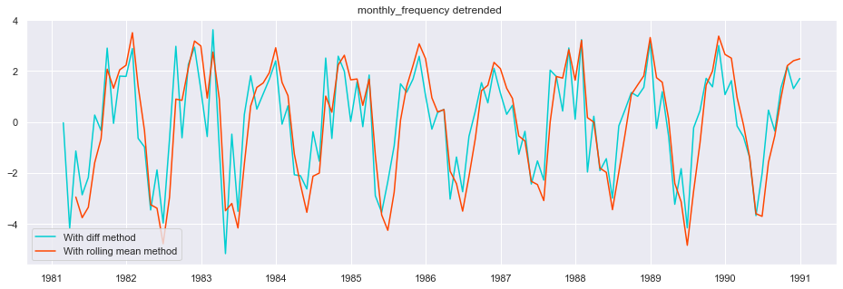

```python
from statsmodels.tsa.statespace.tools import diff
plt.figure(figsize = (16, 5))

# With diff :
monthly_frequency_detrended = diff(monthly_frequency)
plt.plot(monthly_frequency_detrended, color='darkturquoise', label="With diff method")

# With rolling mean :

rolling_mean = monthly_frequency.rolling(4).mean()
monthly_frequency_detrended_rm = monthly_frequency - rolling_mean
plt.plot(monthly_frequency_detrended_rm, color='orangered',label="With rolling mean method")
plt.title("monthly_frequency detrended ")
plt.legend(loc="best")
plt.show()
```

# Remove seasonality

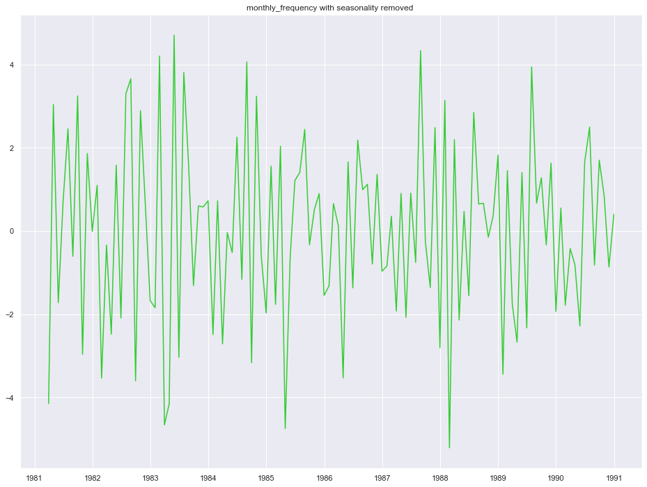

```python
monthly_frequency_detrended_seas = monthly_frequency_detrended - monthly_frequency_detrended.shift()
plt.title("monthly_frequency with seasonality removed ")
plt.plot(monthly_frequency_detrended_seas, color="limegreen")
```

## Autocorrelation and Partial Autocorrelation Functions

Autocorrelation is simply the correlation of a series with its own lags. If a series is significantly autocorrelated, so the previous values of the series (lags) may be helpful in predicting the current value.

Partial Autocorrelation also conveys similar information but it conveys the pure correlation of a series and its lag, excluding the correlation contributions from the intermediate lags.

### We need to do the correlation on detrended model

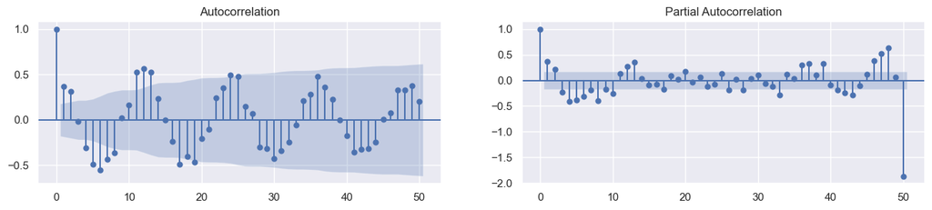

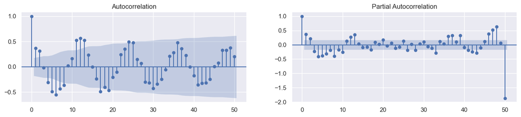

```python
from statsmodels.tsa.stattools import acf, pacf
from statsmodels.graphics.tsaplots import plot_acf, plot_pacf

# Draw Plot
fig, axes = plt.subplots(1,2,figsize=(16,3), dpi= 100)

  # correlation on monthly_frequency
#plot_acf(monthly_frequency['Total Volume'].tolist(), lags=50, ax=axes[0])
#plot_pacf(monthly_frequency['Total Volume'].tolist(), lags=50, ax=axes[1])

  # correlation on detrended monthly_frequency
    # AR term (p)
plot_pacf(monthly_frequency_detrended['Daily temp'].tolist(), lags=50, ax=axes[1])

    # MA term (q)
plot_acf(monthly_frequency_detrended['Daily temp'].tolist(), lags=50, ax=axes[0])
```

# Forecasting

## Linear Regression With Time Series (ARIMA) on monthly_frequency_detrended :

### First, we split the data into training and testing and visualize the split:

```python
#!pip install pmdarima
import pmdarima as pm
from pmdarima.arima import auto_arima
```

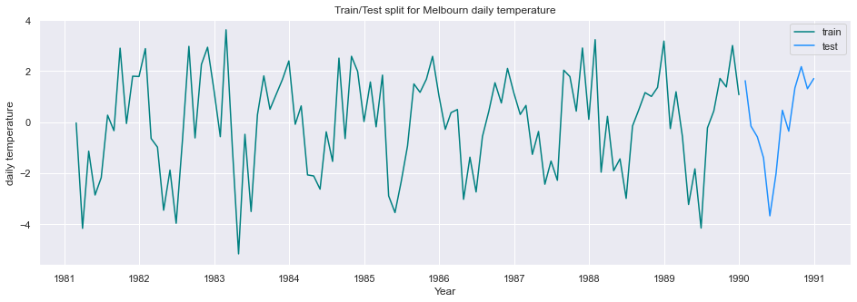

```python
#monthly_frequency['Date'] = monthly_frequency.index

train = monthly_frequency_detrended[monthly_frequency_detrended.index < pd.to_datetime('1990')]
train['train'] = train['Daily temp']
#del train.index
del train['Daily temp']

test = monthly_frequency_detrended[monthly_frequency_detrended.index > pd.to_datetime('1990')]

#del test.index
test['test'] = test['Daily temp']
del test['Daily temp']
plt.figure(figsize = (16, 5))
plt.plot(train, color = "teal", label ='train')
plt.plot(test, color = "dodgerblue", label='test')
plt.title("Train/Test split for Melbourn daily temperature")
plt.ylabel("daily temperature")
plt.xlabel('Year')
plt.legend(loc="best")
sns.set()
plt.show()
```

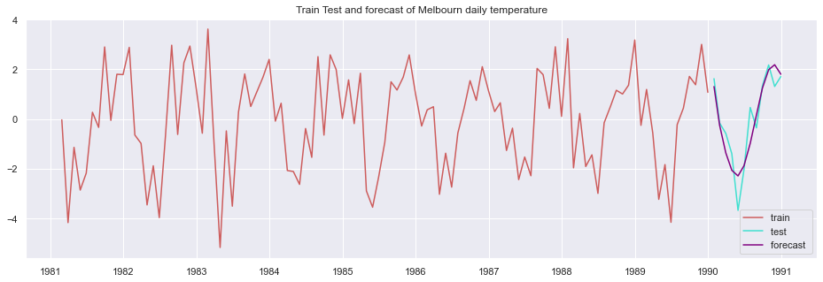

```python
#train_diff = train - train.shift()

model = ARIMA(train, order=(4,0,2),seasonal_order=(0,0,0,12))
result_MA= model.fit()
# make prediction
forecast = result_MA.get_forecast(len(test.index))
forecast_df = forecast.conf_int(alpha = 0.05)
forecast_df["Predictions"] = result_MA.predict(start = forecast_df.index[0], end = forecast_df.index[-1])
forecast_df.index = test.index
y_pred_out = forecast_df["Predictions"]

#forecast = result_MA.predict(n_periods=len(test))
#plt.plot(result_MA.fittedvalues, color='red')
#plt.plot(train_diff, color='blue')
plt.figure(figsize = (16, 5))
plt.plot(train, color='indianred',label="train ")
plt.plot(test, color='turquoise',label="test ")
plt.plot(y_pred_out,color='purple',label="forecast ")
plt.legend(loc="best")
plt.title("Train Test and forecast of Melbourn daily temperature")
```

```python
from math import sqrt
from sklearn.metrics import mean_squared_error
rms = sqrt(mean_squared_error(test,y_pred_out))
print("RMSE: ", rms)
```

```
RMSE:  0.7247505486856967
```

# Verifying with auto_arima that generates automatically (p,d,q)

```python
from pmdarima.arima import auto_arima
#model = auto_arima(train,trace=True, error_action='ignore', suppress_warnings=True)
train.dropna(inplace=True)
model = auto_arima(train,trace=True)
model_fit = model.fit(train)
# make prediction
forecast = model_fit.predict(n_periods=len(test))
forecast = pd.DataFrame(forecast,index = test.index,columns=['Prediction'])
```

```
Performing stepwise search to minimize aic
```

```
 ARIMA(2,0,2)(0,0,0)[0] intercept   : AIC=inf, Time=0.97 sec
 ARIMA(0,0,0)(0,0,0)[0] intercept   : AIC=453.032, Time=0.04 sec
 ARIMA(1,0,0)(0,0,0)[0] intercept   : AIC=441.696, Time=0.08 sec
 ARIMA(0,0,1)(0,0,0)[0] intercept   : AIC=446.494, Time=0.11 sec
 ARIMA(0,0,0)(0,0,0)[0]             : AIC=451.066, Time=0.03 sec
 ARIMA(2,0,0)(0,0,0)[0] intercept   : AIC=438.050, Time=0.09 sec
 ARIMA(3,0,0)(0,0,0)[0] intercept   : AIC=435.012, Time=0.11 sec
 ARIMA(4,0,0)(0,0,0)[0] intercept   : AIC=419.481, Time=0.23 sec
 ARIMA(5,0,0)(0,0,0)[0] intercept   : AIC=405.548, Time=0.17 sec
 ARIMA(5,0,1)(0,0,0)[0] intercept   : AIC=inf, Time=0.99 sec
 ARIMA(4,0,1)(0,0,0)[0] intercept   : AIC=inf, Time=0.96 sec
 ARIMA(5,0,0)(0,0,0)[0]             : AIC=403.590, Time=0.20 sec
 ARIMA(4,0,0)(0,0,0)[0]             : AIC=417.507, Time=0.17 sec
 ARIMA(5,0,1)(0,0,0)[0]             : AIC=inf, Time=1.28 sec
 ARIMA(4,0,1)(0,0,0)[0]             : AIC=inf, Time=0.67 sec

Best model:  ARIMA(5,0,0)(0,0,0)[0]
Total fit time: 6.117 seconds
```

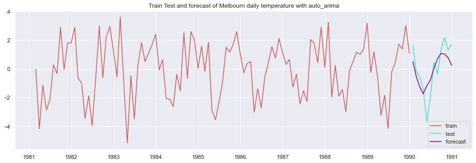

```python
plt.figure(figsize = (16, 5))
plt.plot(train, color='indianred',label="train ")
plt.plot(test, color='turquoise',label="test ")
plt.plot(forecast,color='purple',label="forecast ")
plt.title("Train Test and forecast of Melbourn daily temperature with auto_arima")
plt.legend(loc="best")

plt.show()
```

```python
from math import sqrt
from sklearn.metrics import mean_squared_error
rms = sqrt(mean_squared_error(test,forecast))
print("RMSE: ", rms)
```

```
RMSE:  1.1145387894734042
```

# With SARIMA

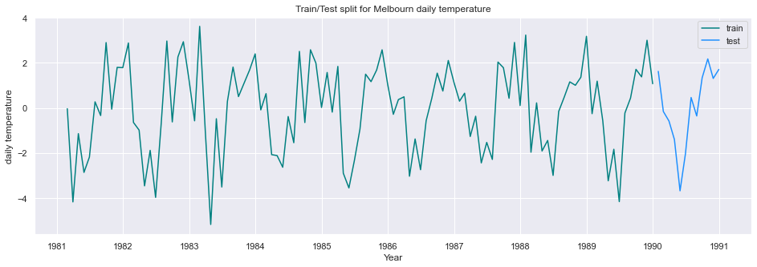

```python
#monthly_frequency['Date'] = monthly_frequency.index

train = monthly_frequency_detrended[monthly_frequency_detrended.index < pd.to_datetime('1990')]
train['train'] = train['Daily temp']
#del train.index
del train['Daily temp']

test = monthly_frequency_detrended[monthly_frequency_detrended.index > pd.to_datetime('1990')]

#del test.index
test['test'] = test['Daily temp']
del test['Daily temp']
plt.figure(figsize = (16, 5))
plt.plot(train, color = "teal", label ='train')
plt.plot(test, color = "dodgerblue", label='test')
plt.title("Train/Test split for Melbourn daily temperature")
plt.ylabel("daily temperature")
plt.xlabel('Year')
plt.legend(loc="best")
sns.set()
plt.show()
```

```python
import statsmodels.api as sm
model=sm.tsa.statespace.SARIMAX(monthly_frequency_detrended['Daily temp'],order=(2,0,2),seasonal_order=(1,1,1,12))
results=model.fit()
```

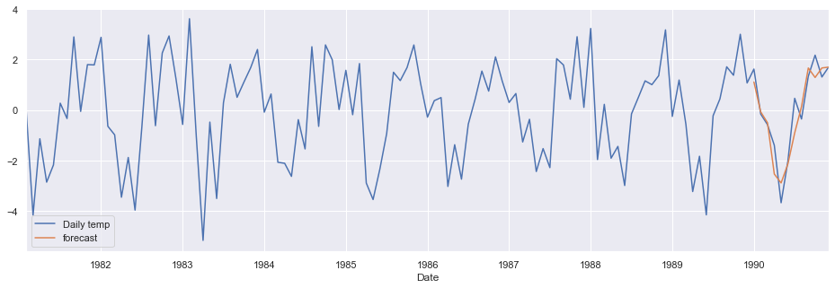

```python
#monthly_frequency_sarima['forecast']=results.predict(start=140,end=203,dynamic=True)
monthly_frequency_sarima = monthly_frequency_detrended
monthly_frequency_sarima['forecast']=results.predict(start=test.index[0],end=test.index[-1])
monthly_frequency_sarima[['Daily temp','forecast']].plot(figsize=(16, 5))
```

```python
df=monthly_frequency_sarima[['Daily temp','forecast']]
df.dropna(inplace=True)
```

```python
from math import sqrt
from sklearn.metrics import mean_squared_error
rms = sqrt(mean_squared_error(df['Daily temp'],df['forecast']))
print("RMSE: ", rms)
```

```
RMSE:  0.6681864478175578
```

SARIMA and ARIMA model are similarly, also auto_arima seems to be the least accurate

I would like to thank you for your course, I enjoyed and found this subject very interesting thanks to you!